# Model Comparison and Selection

This notebook compares multiple models to select the best-performing one for customer churn prediction.

The question guiding this comparison is:

Does a more flexible model provide meaningful improvement over an interpretable baseline, and is that improvement worth the added complexity? Key evaluation metrics include:

- F1-Score - balance between precision and recall
- ROC-AUC - overall model quality
- Precision at high recall - important for catching most churners
- Recall at high precision - important for avoiding wasted interventions

Models compared:

- Baseline: Logistic Regression
- Random Forest

A Random Forest classifier is used as a non-linear benchmark to evaluate whether interactions and non-linear effects improve churn prediction beyond the linear baseline.

```python
import numpy as np
import pandas as pd
from sklearn.ensemble import RandomForestClassifier
from sklearn.metrics import RocCurveDisplay, classification_report, roc_auc_score
import matplotlib.pyplot as plt
from sklearn.linear_model import LogisticRegression
from sklearn.tree import DecisionTreeClassifier
from sklearn.model_selection import train_test_split
from sklearn.pipeline import Pipeline
from sklearn.compose import ColumnTransformer
from sklearn.preprocessing import OneHotEncoder, StandardScaler
from sklearn.impute import SimpleImputer
import warnings

warnings.filterwarnings("ignore")
```

```python
plt.style.use('ggplot')
palette = [
'#E24A33',  #(orange)
'#348ABD',  #(blue)
'#8EBA42',   #(green)
'#988ED5',  #(cyan)
'#777777',  #(grey)
'#FBC15E',  #(yellow)
'#FFB5B8'    #(pink)
]
```

```python
# Load preprocessed data
df = pd.read_csv('../data/ecommerce_churn_data_eda.csv')
```

```python
# Same preproccessing steps are applied as in the baseline model
# Define Target & Drop identifier + leakage-prone features
TARGET = 'Churn'
df.drop(columns=['CustomerID', 'DaySinceLastOrder'], inplace=True)

X = df.drop(columns=[TARGET])
y = df[TARGET]

# Identify numeric vs categorical columns
numeric_features = X.select_dtypes(include=["number"]).columns.tolist()
categorical_features = X.select_dtypes(exclude=["number"]).columns.tolist()

if "CityTier" in numeric_features:
    numeric_features.remove("CityTier")
    categorical_features.append("CityTier")

# Preprocessing pipelines
numeric_transformer = Pipeline(steps=[
    ('imputer', SimpleImputer(strategy='median')),
    ('scaler', StandardScaler())
])
categorical_transformer = Pipeline(steps=[
    ('imputer', SimpleImputer(strategy='constant', fill_value='Unknown')),
    ('onehot', OneHotEncoder(handle_unknown='ignore'))
])

preprocessor = ColumnTransformer(
    transformers=[
        ("num", numeric_transformer, numeric_features),
        ("cat", categorical_transformer, categorical_features),
    ]
)
```

```python
# Train/validation split
test_split = 0.2
X_train, X_test, y_train, y_test = train_test_split(
    X, y,
    test_size=test_split,
    random_state=42,
    stratify=y
)
```

```python
# Function to evaluate model

def evaluate_model(model, X_test, y_test, model_name, y_pred_threshold=None):
    results = {}
    model = Pipeline(steps=[
        ("preprocessor", preprocessor),
        ("classifier", model)
    ])

    model.fit(X_train, y_train)

    y_pred = model.predict(X_test)
    y_proba = model.predict_proba(X_test)[:, 1]

    if y_pred_threshold is not None:
        y_pred = (y_proba >= y_pred_threshold).astype(int)

    report = classification_report(y_test, y_pred, output_dict=True)
    roc_auc = roc_auc_score(y_test, y_proba)

    results[model_name] = {
        "Precision": report["1"]["precision"],
        "Recall": report["1"]["recall"],
        "F1-Score": report["1"]["f1-score"],
        "ROC-AUC": roc_auc
    }

    return results, y_proba
```

```python
# Define the models
log_reg_clf = LogisticRegression(
    max_iter=1000,
    class_weight="balanced",
    random_state=42
)

random_forest_clf = RandomForestClassifier(
    n_estimators=300,
    max_depth=None,
    min_samples_leaf=10,
    class_weight="balanced",
    random_state=42,
    n_jobs=-1
)

models = [
    ("Logistic Regression", log_reg_clf, None, True),
    ("Random Forest", random_forest_clf, None, True),
    ("Logistic Regression t>0.75", log_reg_clf, 0.75, False)
]
```

## Initial Model Evaluation

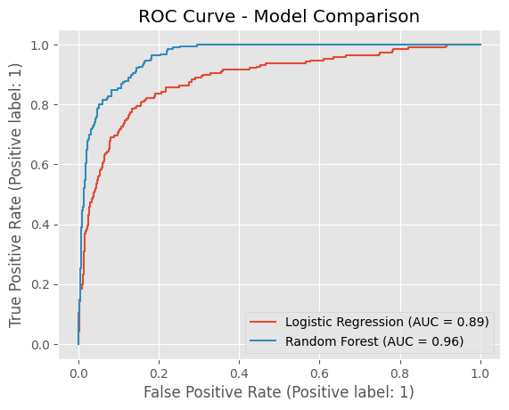

```python
results = {}
roc_auc_scores = {}
for model_name, model, threshold, roc_graph in models:
    model_results, y_proba = evaluate_model(model, X_test, y_test, model_name, y_pred_threshold=threshold)
    results.update(model_results)
    roc_auc_scores[model_name] = y_proba

fig, ax = plt.subplots()
model_names = list(roc_auc_scores.keys())
roc_aucs = list(roc_auc_scores.values())
for model_name, _, _, roc_graph in models:
    if roc_graph:
        RocCurveDisplay.from_predictions(y_test, roc_auc_scores[model_name], ax=ax, name=model_name, color = palette[model_names.index(model_name)])
plt.title("ROC Curve - Model Comparison")
plt.show()
```

```python
# ROC-AUC scores
roc_auc_df = pd.DataFrame.from_dict(results, orient='index')[['ROC-AUC']]
roc_auc_df = roc_auc_df.sort_values(by="ROC-AUC", ascending=False).loc[['Random Forest', 'Logistic Regression']]
roc_auc_df
```

|  | ROC-AUC |
| --- | --- |
| Random Forest | 0.960824 |
| Logistic Regression | 0.885256 |

Comparing ROC-AUC scores shows that the Random Forest model outperforms the Logistic Regression baseline, indicating better overall discrimination between churners and non-churners.

## Threshold Optimization for Business-aligned Metrics

```python
opt_results = []
model_results, y_proba = evaluate_model(random_forest_clf, X_test, y_test, "Random Forest", None)
thresholds = np.arange(0.1, 0.9, 0.05)
for threshold in thresholds:
    y_pred_threshold = (y_proba >= threshold).astype(int)
    report = classification_report(y_test, y_pred_threshold, output_dict=True)
    opt_results.append({
        "threshold": threshold,
        "precision": report["1"]["precision"],
        "recall": report["1"]["recall"],
        "f1-score": report["1"]["f1-score"]
    })
opt_results_df = pd.DataFrame(opt_results)
```

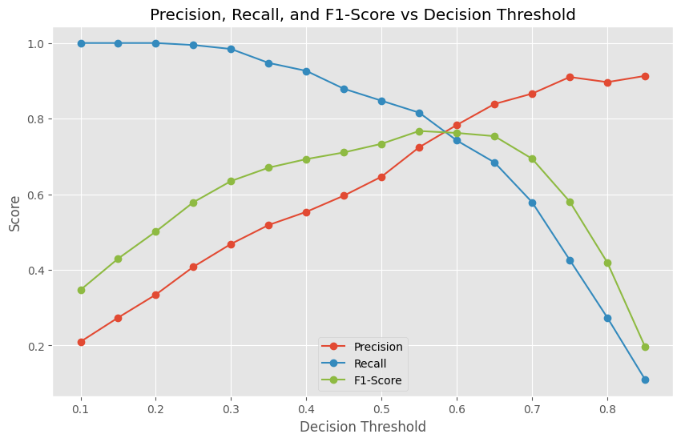

```python
# Plot Precision-Recall vs Threshold
plt.figure(figsize=(10, 6))
plt.plot(opt_results_df["threshold"], opt_results_df["precision"], label="Precision", marker='o', color=palette[0])
plt.plot(opt_results_df["threshold"], opt_results_df["recall"], label="Recall", marker='o', color=palette[1])
plt.plot(opt_results_df["threshold"], opt_results_df["f1-score"], label="F1-Score", marker='o', color=palette[2])
plt.xlabel("Decision Threshold")
plt.ylabel("Score")
plt.title("Precision, Recall, and F1-Score vs Decision Threshold")
plt.legend()
plt.show()
```

Based on this, a threshold of 0.55 is selected for the Random Forest model to balance precision and recall.

```python
# Evaluate all models with default and selected thresholds
models.append(
    ("Random Forest t>0.55", random_forest_clf, 0.55, False)
)

results = {}
for model_name, model, threshold, roc_graph in models:
    model_results, y_proba = evaluate_model(model, X_test, y_test, model_name, y_pred_threshold=threshold)
    results.update(model_results)
```

```python
# Business-aligned decision performance
results_df = pd.DataFrame(results).T
results_df = results_df.sort_values(by="F1-Score", ascending=False).drop(columns=["ROC-AUC"])
results_df
```

|  | Precision | Recall | F1-Score |
| --- | --- | --- | --- |
| Random Forest t>0.55 | 0.724299 | 0.815789 | 0.767327 |
| Random Forest | 0.646586 | 0.847368 | 0.733485 |
| Logistic Regression t>0.75 | 0.638743 | 0.642105 | 0.640420 |
| Logistic Regression | 0.463557 | 0.836842 | 0.596623 |

## Conclusion on Model Comparison

Evaluating business-aligned metrics at selected decision thresholds further highlights the Random Forest's superiority: The Random Forest model with a decision threshold of 0.55 outperforms the baseline Logistic Regression model (threshold 0.75) across all key metrics:

- F1-Score: 0.77 vs 0.64
- Precision: 0.72 vs 0.64
- Recall: 0.82 vs 0.64

This performance gain comes at the cost of reduced interpretability compared to Logistic Regression.